# Stats Project

Yasshin Lozano

# Part 1: Introduction

The data set I used was based on a summer research I participated in: The Evaluation of an autonomous vehicle utilizing self-adpative controller for onstacle avoidance.

[figure not shown]

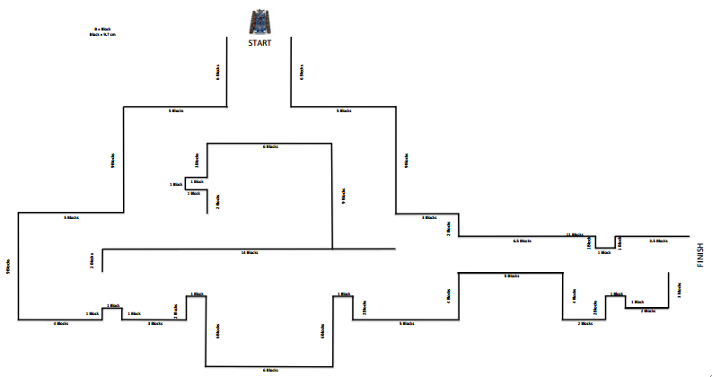

Does sensitivity vs efficiency have an effect on the outcome of the autonomous rover through two different mazes, if so what would be the optimal setup for each maze? Based on the setup of rover, which consist of the sensitivity of the infrared sensor, ultra-sonic sensor, distance of nudge threshold in inches, nudge turn degree, and motor speed, we can predict the efficiency percentage of each maze.

This type of small scale research can benefit self-driving cars such as the Tesla to find the optimal speed and sensitivity setup to go at without crashing into something for each city. All cities and counties are different so different setups are need to reduce, and hopefully negate, the chance of the car causing an accident.

Background of predictor variables: The infrared threshold is a measurement of how “bright” an object is based on the reflected light. The ultrasonic threshold is a measurement of distance using ultrasonic waves that echo back the measurement. The nudge threshold tells the rover when to adjust itself when it thinks it might hit a wall based on how far it detects the object. In this case the nudge threshold is measured in inches. The nudge is the degree the rover will turn when detecting a wall. The motor speed controls how fast the motors on the rover are going.

# Part 2: Exploratory data analysis

```r
library(tidyverse)
library(dplyr)
library(lubridate)
library(readr)
library(car)
Maze_Data <- read.csv(file="J:/MASTERS/Stats/Project/MaDa.csv",  header = T, sep = ",")
Maze1 <- read.csv(file="J:/MASTERS/Stats/Project/Maze1.csv",  header = T, sep = ",")
Maze2 <- read.csv(file="J:/MASTERS/Stats/Project/Maze2.csv",  header = T, sep = ",")
```

```r
summary(Maze_Data)
```

```
                    MTT          Time
 Maze_1_Test_1_Trial_1: 1   Min.   :  0.0
 Maze_1_Test_1_Trial_2: 1   1st Qu.:  0.0
 Maze_1_Test_1_Trial_3: 1   Median :112.5
 Maze_1_Test_1_Trial_4: 1   Mean   :143.2
 Maze_1_Test_1_Trial_5: 1   3rd Qu.:198.8
 Maze_1_Test_2_Trial_1: 1   Max.   :707.0
 (Other)              :64
   Pass.Score          Pass              OD
 Min.   :0.0000   Min.   :0.0000   Min.   : 1.00
 1st Qu.:0.0000   1st Qu.:0.0000   1st Qu.: 6.00
 Median :0.6250   Median :1.0000   Median :10.00
 Mean   :0.5267   Mean   :0.6857   Mean   :12.07
 3rd Qu.:0.8750   3rd Qu.:1.0000   3rd Qu.:16.75
 Max.   :1.0000   Max.   :1.0000   Max.   :56.00

     Nudges           Crashes        IR_Threshold
 Min.   :   6.00   Min.   :0.0000   Min.   :0.600
 1st Qu.:  97.25   1st Qu.:0.0000   1st Qu.:0.904
 Median : 191.00   Median :1.0000   Median :1.504
 Mean   : 298.36   Mean   :0.6143   Mean   :1.373
 3rd Qu.: 320.50   3rd Qu.:1.0000   3rd Qu.:1.800
 Max.   :1901.00   Max.   :2.0000   Max.   :1.800

  US_Threshold   Nudge_Threshold     Nudge
 Min.   :0.600   Min.   :2       Min.   :10
 1st Qu.:0.600   1st Qu.:2       1st Qu.:10
 Median :1.200   Median :4       Median :20
 Mean   :1.206   Mean   :4       Mean   :20
 3rd Qu.:1.800   3rd Qu.:6       3rd Qu.:30
 Max.   :1.800   Max.   :6       Max.   :30

  Motor.Speed      Sensitivity
 Min.   :0.5000   Min.   :13.7
 1st Qu.:0.5000   1st Qu.:15.4
 Median :1.0000   Median :27.4
 Mean   :0.8214   Mean   :27.4
 3rd Qu.:1.0000   3rd Qu.:40.1
 Max.   :1.0000   Max.   :40.6
```

```r
#Predictors are the thresholds, nudge and motor.speed. Sensitivity is the sum of the predictors.
predictors <- Maze_Data[ ,8:12]
pm <- sapply(predictors, sd)
```

The predictors are what effect the pass score.

```r
summary(Maze1)
```

```
                    MTT          Time
 Maze_1_Test_1_Trial_1: 1   Min.   :  0.0
 Maze_1_Test_1_Trial_2: 1   1st Qu.: 42.0
 Maze_1_Test_1_Trial_3: 1   Median :132.0
 Maze_1_Test_1_Trial_4: 1   Mean   :168.0
 Maze_1_Test_1_Trial_5: 1   3rd Qu.:273.5
 Maze_1_Test_2_Trial_1: 1   Max.   :707.0
 (Other)              :29
   Pass.Score          Pass              OD
 Min.   :0.0000   Min.   :0.0000   Min.   : 2.00
 1st Qu.:0.6040   1st Qu.:1.0000   1st Qu.: 6.50
 Median :0.6670   Median :1.0000   Median :12.00
 Mean   :0.6262   Mean   :0.8286   Mean   :12.66
 3rd Qu.:0.8750   3rd Qu.:1.0000   3rd Qu.:19.00
 Max.   :1.0000   Max.   :1.0000   Max.   :30.00

     Nudges          Crashes        IR_Threshold
 Min.   :   6.0   Min.   :0.0000   Min.   :0.600
 1st Qu.: 115.5   1st Qu.:0.0000   1st Qu.:0.904
 Median : 209.0   Median :1.0000   Median :1.504
 Mean   : 311.7   Mean   :0.6286   Mean   :1.373
 3rd Qu.: 357.0   3rd Qu.:1.0000   3rd Qu.:1.800
 Max.   :1645.0   Max.   :2.0000   Max.   :1.800

  US_Threshold   Nudge_Threshold     Nudge
 Min.   :0.600   Min.   :2       Min.   :10
 1st Qu.:0.600   1st Qu.:2       1st Qu.:10
 Median :1.200   Median :4       Median :20
 Mean   :1.206   Mean   :4       Mean   :20
 3rd Qu.:1.800   3rd Qu.:6       3rd Qu.:30
 Max.   :1.800   Max.   :6       Max.   :30

  Motor.Speed      Sensitivity
 Min.   :0.5000   Min.   :13.7
 1st Qu.:0.5000   1st Qu.:15.4
 Median :1.0000   Median :27.4
 Mean   :0.8214   Mean   :27.4
 3rd Qu.:1.0000   3rd Qu.:40.1
 Max.   :1.0000   Max.   :40.6
```

```r
summary(Maze2)
```

```
                    MTT          Time
 Maze_2_Test_1_Trial_1: 1   Min.   :  0.0
 Maze_2_Test_1_Trial_2: 1   1st Qu.:  0.0
 Maze_2_Test_1_Trial_3: 1   Median : 46.0
 Maze_2_Test_1_Trial_4: 1   Mean   :118.5
 Maze_2_Test_1_Trial_5: 1   3rd Qu.:177.0
 Maze_2_Test_2_Trial_1: 1   Max.   :633.0
 (Other)              :29
   Pass.Score          Pass              OD
 Min.   :0.0000   Min.   :0.0000   Min.   : 1.00
 1st Qu.:0.0000   1st Qu.:0.0000   1st Qu.: 5.00
 Median :0.4160   Median :1.0000   Median :10.00
 Mean   :0.4272   Mean   :0.5429   Mean   :11.49
 3rd Qu.:0.8750   3rd Qu.:1.0000   3rd Qu.:14.00
 Max.   :1.0000   Max.   :1.0000   Max.   :56.00

     Nudges          Crashes     IR_Threshold
 Min.   :  10.0   Min.   :0.0   Min.   :0.600
 1st Qu.:  85.5   1st Qu.:0.0   1st Qu.:0.904
 Median : 138.0   Median :0.0   Median :1.504
 Mean   : 285.1   Mean   :0.6   Mean   :1.373
 3rd Qu.: 305.5   3rd Qu.:1.0   3rd Qu.:1.800
 Max.   :1901.0   Max.   :2.0   Max.   :1.800

  US_Threshold   Nudge_Threshold     Nudge
 Min.   :0.600   Min.   :2       Min.   :10
 1st Qu.:0.600   1st Qu.:2       1st Qu.:10
 Median :1.200   Median :4       Median :20
 Mean   :1.206   Mean   :4       Mean   :20
 3rd Qu.:1.800   3rd Qu.:6       3rd Qu.:30
 Max.   :1.800   Max.   :6       Max.   :30

  Motor.Speed      Sensitivity
 Min.   :0.5000   Min.   :13.7
 1st Qu.:0.5000   1st Qu.:15.4
 Median :1.0000   Median :27.4
 Mean   :0.8214   Mean   :27.4
 3rd Qu.:1.0000   3rd Qu.:40.1
 Max.   :1.0000   Max.   :40.6
```

```r
cor(Sensitivity, Pass.Score)
```

```
[1] -0.5182282
```

I am checking the correlation of the sensitivity on the pass score. It has a moderate downhill linear relationship. Meaning as the sensitivity goes up the pass score goes slightly down. In numbers this is true, but in fact during the physical experiment the sensitivity was somewhat the same as you will see in the folowwing graphs.

```r
cor(Maze_Data$IR_Threshold, Maze_Data$Pass.Score)
```

```
[1] -0.04570114
```

```r
cor(Maze_Data$US_Threshold, Maze_Data$Pass.Score)
```

```
[1] -0.2748036
```

```r
cor(Maze_Data$Nudge_Threshold, Maze_Data$Pass.Score)
```

```
[1] -0.2745998
```

```r
cor(Maze_Data$Nudge, Maze_Data$Pass.Score)
```

```
[1] -0.2745998
```

```r
cor(Maze_Data$Motor.Speed, Maze_Data$Pass.Score)
```

```
[1] 0.3367385
```

If the ‘Sensitivity’ does not have that much of an impact, even though it should, I wanted to see which threshold is effecting the pass score the most. ‘IR_Threshold’ had the least correlation with the ‘Pass.Score’. ‘US_Threshold’, ‘Nudge_Threshold’ and ‘Nudge’ all had the same correlation on the ‘Pass.Score’. The ‘Motor.Speed’ had the biggest effect on the ‘Pass.Score’ as expected.

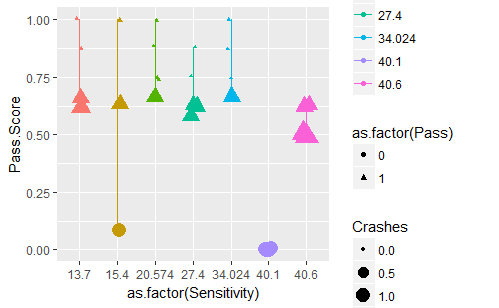

```r
ggplot(Maze1, aes(x=as.factor(Sensitivity), y=Pass.Score, shape = as.factor(Pass), color = as.factor(Sensitivity), group = as.factor(Sensitivity))) + geom_point(aes(size=Crashes), position = position_jitter(w=0.1, h=0.01)) + geom_line()
```

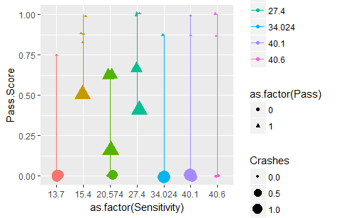

```r
ggplot(Maze2, aes(x=as.factor(Sensitivity), y=Pass.Score, shape = as.factor(Pass), color = as.factor(Sensitivity), group = as.factor(Sensitivity)))+
  geom_point(aes(size=Crashes),position = position_jitter(w=0.1, h=0.01)) + geom_line()
```

```r
gm <- lm(Maze1$Pass.Score ~ Maze1$Sensitivity)
summary(gm)
```

```
Call:
lm(formula = Maze1$Pass.Score ~ Maze1$Sensitivity)

Residuals:
     Min       1Q   Median       3Q      Max
-0.73105 -0.18136  0.08044  0.19570  0.47750

Coefficients:
                   Estimate Std. Error t value Pr(>|t|)
(Intercept)        1.055130   0.131809   8.005  3.1e-09
Maze1$Sensitivity -0.015655   0.004497  -3.481  0.00143

(Intercept)       ***
Maze1$Sensitivity **
---
Signif. codes:
0 *** 0.001 ** 0.01 * 0.05 . 0.1   1

Residual standard error: 0.2768 on 33 degrees of freedom
Multiple R-squared:  0.2686,    Adjusted R-squared:  0.2464
F-statistic: 12.12 on 1 and 33 DF,  p-value: 0.001428
```

The estimated passing score when we consider the average of sensitivity across all data sets in Maze 1 is 0.62

### Residuals

The distribution of the residuals do not appear to be strongly symmetrical. That means that the model predicts certain points that fall far away from the actual observed points. In our case it can predict the ‘Pass.Score’ wrongly based on the ‘Sensitivity’.

```r
hist(gm$residuals)
```

[output not shown]

### Coefficients

**Second row:** The effect ‘Sensitivity’ has on ‘Pass.Score’ required for the rover to complete Maze 1. The slope term in our model is saying that for every 1 unit increase in the ‘Sensitivity’ of the rover, the ‘Pass.Score’ decreased by 1.5655%

### Multiple R-squared and Adjusted R-squared

The R^2 we get is 0.2686 or 26.86% of the variance found in the response variable ‘Pass.Score’ cab be explained by the predictor variabl ‘Sensitivity’.

```r
m1.lm <- lm(Pass.Score ~ IR_Threshold + US_Threshold + Nudge_Threshold + Nudge + Motor.Speed, data = Maze1)
m1P <- predict(m1.lm, list(IR_Threshold = 0.600, US_Threshold = 0.60, Nudge_Threshold = 2, Nudge = 10, Motor.Speed = 0.5))
```

```
prediction from a rank-deficient fit may be misleading
```

```r
m1P
```

```
        1
0.6796667
```

```r
summary(m1.lm)
```

```
Call:
lm(formula = Pass.Score ~ IR_Threshold + US_Threshold + Nudge_Threshold +
    Nudge + Motor.Speed, data = Maze1)

Residuals:
     Min       1Q   Median       3Q      Max
-0.65860 -0.07432 -0.01267  0.13598  0.32033

Coefficients: (1 not defined because of singularities)
                Estimate Std. Error t value Pr(>|t|)
(Intercept)       0.5579     0.1465   3.809 0.000644 ***
IR_Threshold     -0.3102     0.1123  -2.763 0.009695 **
US_Threshold      5.8382     4.0568   1.439 0.160473
Nudge_Threshold  -1.8146     1.2242  -1.482 0.148702
Nudge                 NA         NA      NA       NA
Motor.Speed       0.8682     0.1789   4.854 3.51e-05 ***
---
Signif. codes:
0 *** 0.001 ** 0.01 * 0.05 . 0.1   1

Residual standard error: 0.1951 on 30 degrees of freedom
Multiple R-squared:  0.6697,    Adjusted R-squared:  0.6256
F-statistic:  15.2 on 4 and 30 DF,  p-value: 6.723e-07
```

```r
m2.lm <- lm(Pass.Score ~ IR_Threshold + US_Threshold + Nudge_Threshold + Nudge + Motor.Speed, data = Maze2)
m2P <- predict(m2.lm, list(IR_Threshold = 0.2, US_Threshold = 0.6, Nudge_Threshold = 2, Nudge = 10, Motor.Speed = 1))
```

```
prediction from a rank-deficient fit may be misleading
```

```r
m2P
```

```
        1
0.5484599
```

```r
summary(m2.lm)
```

```
Call:
lm(formula = Pass.Score ~ IR_Threshold + US_Threshold + Nudge_Threshold +
    Nudge + Motor.Speed, data = Maze2)

Residuals:
    Min      1Q  Median      3Q     Max
-0.5522 -0.2861 -0.1678  0.4162  0.7414

Coefficients: (1 not defined because of singularities)
                 Estimate Std. Error t value Pr(>|t|)
(Intercept)       0.05997    0.29993   0.200   0.8429
IR_Threshold      0.16759    0.22988   0.729   0.4716
US_Threshold    -14.13135    8.30700  -1.701   0.0993 .
Nudge_Threshold   4.17331    2.50679   1.665   0.1064
Nudge                  NA         NA      NA       NA
Motor.Speed       0.58717    0.36624   1.603   0.1194
---
Signif. codes:
0 *** 0.001 ** 0.01 * 0.05 . 0.1   1

Residual standard error: 0.3995 on 30 degrees of freedom
Multiple R-squared:  0.2486,    Adjusted R-squared:  0.1485
F-statistic: 2.482 on 4 and 30 DF,  p-value: 0.06495
```

```r
summary(m1P)
```

```
   Min. 1st Qu.  Median    Mean 3rd Qu.    Max.
 0.6797  0.6797  0.6797  0.6797  0.6797  0.6797
```

```r
summary(m2P)
```

```
   Min. 1st Qu.  Median    Mean 3rd Qu.    Max.
 0.5485  0.5485  0.5485  0.5485  0.5485  0.5485
```

```r
qqPlot(Pass.Score, col = Sensitivity)
```

[output not shown]

```r
Best_Runs1 <- filter(Maze1, Crashes == 0, Pass == 1, Pass.Score >= 0.8)
Best_Runs1
```

| MTT | Time | Pass.Score | Pass | OD | Nudges | Crashes | IR_Threshold | US_Threshold | Nudge_Threshold | Nudge | Motor.Speed | Sensitivity |
| --- | --- | --- | --- | --- | --- | --- | --- | --- | --- | --- | --- | --- |
| Maze_1_Test_1_Trial_3 | 170 | 0.875 | 1 | 13 | 292 | 0 | 0.600 | 0.60 | 2 | 10 | 0.50 | 13.700 |
| Maze_1_Test_1_Trial_4 | 139 | 1.000 | 1 | 10 | 166 | 0 | 0.600 | 0.60 | 2 | 10 | 0.50 | 13.700 |
| Maze_1_Test_2_Trial_1 | 270 | 0.875 | 1 | 19 | 232 | 0 | 0.904 | 0.92 | 3 | 15 | 0.75 | 20.574 |
| Maze_1_Test_2_Trial_2 | 367 | 1.000 | 1 | 24 | 389 | 0 | 0.904 | 0.92 | 3 | 15 | 0.75 | 20.574 |
| Maze_1_Test_3_Trial_1 | 297 | 0.875 | 1 | 19 | 248 | 0 | 1.200 | 1.20 | 4 | 20 | 1.00 | 27.400 |
| Maze_1_Test_4_Trial_2 | 200 | 1.000 | 1 | 17 | 109 | 0 | 1.504 | 1.52 | 5 | 25 | 1.00 | 34.024 |
| Maze_1_Test_4_Trial_5 | 43 | 0.875 | 1 | 13 | 208 | 0 | 1.504 | 1.52 | 5 | 25 | 1.00 | 34.024 |
| Maze_1_Test_6_Trial_1 | 109 | 1.000 | 1 | 6 | 195 | 0 | 1.800 | 0.60 | 2 | 10 | 1.00 | 15.400 |
| Maze_1_Test_6_Trial_2 | 129 | 1.000 | 1 | 8 | 253 | 0 | 1.800 | 0.60 | 2 | 10 | 1.00 | 15.400 |
| Maze_1_Test_6_Trial_5 | 132 | 1.000 | 1 | 9 | 209 | 0 | 1.800 | 0.60 | 2 | 10 | 1.00 | 15.400 |

```r
Worst_Runs1 <- filter(Maze1, Crashes == 1, Pass == 0, Pass.Score < 0.8)
Worst_Runs1
```

| MTT | Time | Pass.Score | Pass | OD | Nudges | Crashes | IR_Threshold | US_Threshold | Nudge_Threshold | Nudge | Motor.Speed | Sensitivity |
| --- | --- | --- | --- | --- | --- | --- | --- | --- | --- | --- | --- | --- |
| Maze_1_Test_6_Trial_4 | 0 | 0.083 | 0 | 24 | 405 | 1 | 1.8 | 0.6 | 2 | 10 | 1.0 | 15.4 |
| Maze_1_Test_7_Trial_1 | 0 | 0.000 | 0 | 9 | 1645 | 1 | 1.8 | 1.8 | 6 | 30 | 0.5 | 40.1 |
| Maze_1_Test_7_Trial_2 | 0 | 0.000 | 0 | 12 | 761 | 1 | 1.8 | 1.8 | 6 | 30 | 0.5 | 40.1 |
| Maze_1_Test_7_Trial_3 | 0 | 0.000 | 0 | 7 | 165 | 1 | 1.8 | 1.8 | 6 | 30 | 0.5 | 40.1 |
| Maze_1_Test_7_Trial_4 | 0 | 0.000 | 0 | 11 | 683 | 1 | 1.8 | 1.8 | 6 | 30 | 0.5 | 40.1 |
| Maze_1_Test_7_Trial_5 | 0 | 0.000 | 0 | 8 | 560 | 1 | 1.8 | 1.8 | 6 | 30 | 0.5 | 40.1 |

```r
Best_Runs2 <- filter(Maze2, Crashes == 0, Pass == 1, Pass.Score >= 0.8)
Best_Runs2
```

| MTT | Time | Pass.Score | Pass | OD | Nudges | Crashes | IR_Threshold | US_Threshold | Nudge_Threshold | Nudge | Motor.Speed | Sensitivity |
| --- | --- | --- | --- | --- | --- | --- | --- | --- | --- | --- | --- | --- |
| Maze_2_Test_3_Trial_1 | 142 | 1.000 | 1 | 10 | 133 | 0 | 1.200 | 1.20 | 4 | 20 | 1.0 | 27.400 |
| Maze_2_Test_3_Trial_4 | 161 | 1.000 | 1 | 14 | 105 | 0 | 1.200 | 1.20 | 4 | 20 | 1.0 | 27.400 |
| Maze_2_Test_3_Trial_5 | 116 | 1.000 | 1 | 9 | 78 | 0 | 1.200 | 1.20 | 4 | 20 | 1.0 | 27.400 |
| Maze_2_Test_4_Trial_2 | 171 | 0.875 | 1 | 14 | 124 | 0 | 1.504 | 1.52 | 5 | 25 | 1.0 | 34.024 |
| Maze_2_Test_5_Trial_1 | 130 | 1.000 | 1 | 10 | 147 | 0 | 1.800 | 1.80 | 6 | 30 | 1.0 | 40.600 |
| Maze_2_Test_5_Trial_5 | 628 | 0.875 | 1 | 6 | 98 | 0 | 1.800 | 1.80 | 6 | 30 | 1.0 | 40.600 |
| Maze_2_Test_6_Trial_1 | 46 | 0.875 | 1 | 3 | 115 | 0 | 1.800 | 0.60 | 2 | 10 | 1.0 | 15.400 |
| Maze_2_Test_6_Trial_2 | 43 | 0.833 | 1 | 3 | 59 | 0 | 1.800 | 0.60 | 2 | 10 | 1.0 | 15.400 |
| Maze_2_Test_6_Trial_3 | 203 | 0.875 | 1 | 14 | 304 | 0 | 1.800 | 0.60 | 2 | 10 | 1.0 | 15.400 |
| Maze_2_Test_6_Trial_5 | 482 | 1.000 | 1 | 5 | 68 | 0 | 1.800 | 0.60 | 2 | 10 | 1.0 | 15.400 |

[output cut: 2 more lines]

```r
Worst_Runs2 <- filter(Maze2, Crashes == 1, Pass == 0, Pass.Score < 0.8)
Worst_Runs2
```

| MTT | Time | Pass.Score | Pass | OD | Nudges | Crashes | IR_Threshold | US_Threshold | Nudge_Threshold | Nudge | Motor.Speed | Sensitivity |
| --- | --- | --- | --- | --- | --- | --- | --- | --- | --- | --- | --- | --- |
| Maze_2_Test_1_Trial_2 | 0 | 0 | 0 | 1 | 365 | 1 | 0.600 | 0.60 | 2 | 10 | 0.50 | 13.700 |
| Maze_2_Test_1_Trial_3 | 0 | 0 | 0 | 11 | 286 | 1 | 0.600 | 0.60 | 2 | 10 | 0.50 | 13.700 |
| Maze_2_Test_1_Trial_4 | 0 | 0 | 0 | 8 | 228 | 1 | 0.600 | 0.60 | 2 | 10 | 0.50 | 13.700 |
| Maze_2_Test_1_Trial_5 | 0 | 0 | 0 | 11 | 493 | 1 | 0.600 | 0.60 | 2 | 10 | 0.50 | 13.700 |
| Maze_2_Test_2_Trial_5 | 0 | 0 | 0 | 1 | 818 | 1 | 0.904 | 0.92 | 3 | 15 | 0.75 | 20.574 |
| Maze_2_Test_4_Trial_5 | 0 | 0 | 0 | 7 | 967 | 1 | 1.504 | 1.52 | 5 | 25 | 1.00 | 34.024 |
| Maze_2_Test_7_Trial_3 | 0 | 0 | 0 | 17 | 662 | 1 | 1.800 | 1.80 | 6 | 30 | 0.50 | 40.100 |
| Maze_2_Test_7_Trial_5 | 0 | 0 | 0 | 45 | 679 | 1 | 1.800 | 1.80 | 6 | 30 | 0.50 | 40.100 |

These are the best and worst runs for Maze 1 and Maze 2

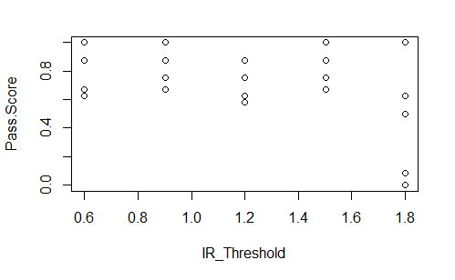

```r
plot(IR_Threshold, Pass.Score)
```

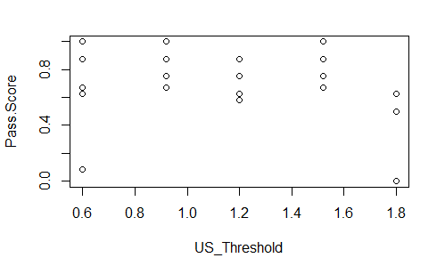

```r
plot(US_Threshold, Pass.Score)
```

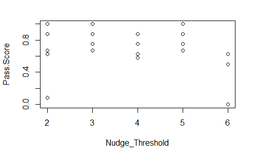

```r
plot(Nudge_Threshold, Pass.Score)
```

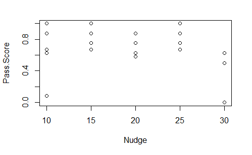

```r
plot(Nudge, Pass.Score)
```

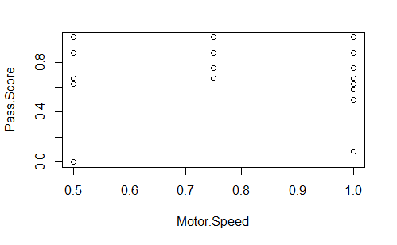

```r
plot(Motor.Speed, Pass.Score)
```

The higher the thresholds got the worst the rover performed in some cases.

# Part4: Conclusion

The data collected after the evaluation of the system shows that the speed at which the rover reacts to stimuli detected by its sensors (IR and Ultra Sonic Sensors) is a key internal factor that directly affects all internal and external elements. With a rover movement velocity set to 100% and 75% percent of the maximum, the rover performed wrong-way completions (completions were not defined as factors but rather a score, so a wrong way can be valued as 0.75), defined as exiting the track test from the initial entry point. On the other hand, when the rover’s movement velocity was set to 50% of the maximum, the rover performed as expected with zero wrong-way completions. However, the data also demonstrated that with 50% percent movement velocity, the rover was able to successfully complete the track tests 50% of the time. When the movement velocity was set to 75% and 100%, the rover was able to complete the track tests 60% and 80% of the time, respectively.